# Clean.5 In Class Starter (Outliers and Date-Time)

Your Name

2/9/2022

# Import Dataset

Import the irs_nonprofit2018 dataset. Explore it in the console and the global environment.

# Outliers

(Credit to https://statsandr.com/blog/outliers-detection-in-r/ for some of this code.)

As we consider outliers, we need to remember that there are two main types of outliers that should be distinguished: 1) mistaken data, 2) extreme values.

We also can consider that there are different definitions of what constitues an outlier. We will talk about several of them.

## Review of what we know

We already know several ways to find outliers. One of the most straight forward is to just look at the min and max of our numeric variables. We can output all of these at once by using the summary function.

Use the summary function to look at the dataset. Do you see any outliers? How would you know?

```
##                                              name_org             city
##  BENEVOLENT & PROTECTIVE ORDER OF ELKS           :  15   NEW YORK   :  60
##  BENEVOLENT & PROTECTIVE ORDER OF ELKS OF THE USA:  13   WASHINGTON :  53
##  FRATERNAL ORDER OF EAGLES                       :  11   LOS ANGELES:  38
##  Benevolent & Protective Order of Elks of the USA:   9   ALEXANDRIA :  37
##  BENEVOLENT & PROTECTIVE ORDER OF                :   7   COLUMBIA   :  37
##  BENEVOLENT AND PROTECTIVE ORDER OF              :   7   LONG BEACH :  35
##  (Other)                                         :8177   (Other)    :7979
##      state       formation_yr  exempt_status.501c3 gross_receipts
##  CA     : 844   Min.   :1681   Mode:logical        Min.   :0.000e+00
##  NY     : 609   1st Qu.:1959   TRUE:4922           1st Qu.:1.639e+05
##  FL     : 418   Median :1982   NA's:3317           Median :3.232e+05
##  PA     : 368   Mean   :1974                       Mean   :1.735e+06
##  IL     : 330   3rd Qu.:1998                       3rd Qu.:7.838e+05
##  (Other):5668   Max.   :2017                       Max.   :1.056e+09
##  NA's   :   2   NA's   :931
##  voting_memb_ct     income_tot_unrelated fundraise_expense_tot_curyr
##  Min.   :    0.00   Min.   :-311919      Min.   :   -1742
##  1st Qu.:    6.00   1st Qu.:      0      1st Qu.:       0
##  Median :    9.00   Median :      0      Median :       0
##  Mean   :   36.34   Mean   :   8154      Mean   :   26842
##  3rd Qu.:   13.00   3rd Qu.:      0      3rd Qu.:       0
##  Max.   :35146.00   Max.   :3234375      Max.   :15330209
##
##  asset_tot_beginyr   rev_giftsgrants_tot_curyr rev_investmt_curyr
##  Min.   : -5431065   Min.   :        0         Min.   :-6977416
##  1st Qu.:   169056   1st Qu.:      367         1st Qu.:       3
##  Median :   519134   Median :    33567         Median :     245
##  Mean   :  2672009   Mean   :   609591         Mean   :   61578
##  3rd Qu.:  1374574   3rd Qu.:   181648         3rd Qu.:    6438
##  Max.   :778124909   Max.   :704248801         Max.   :44681898
##  NA's   :63
##  rev_prgmservice_curyr rev_tot_curyr       grants_expense_tot_curyr
##  Min.   :      -52     Min.   : -4781906   Min.   :    -2544
##  1st Qu.:        0     1st Qu.:   117856   1st Qu.:        0
##  Median :    39034     Median :   252630   Median :        0
##  Mean   :   635761     Mean   :  1380039   Mean   :   161373
##  3rd Qu.:   261417     3rd Qu.:   604287   3rd Qu.:     2000
##  Max.   :290939912     Max.   :712607258   Max.   :253101533
##
```

[output cut: 17 more lines]

```
##  Min.   :-245794076   no :7766            no :5774
##  1st Qu.:    114355   yes: 473            yes:2465
##  Median :    398765
##  Mean   :   1963598
##  3rd Qu.:   1070896
##  Max.   : 699546633
##
##  conflict_interest_policy enforce_conflict_policy whistleblower_policy
##  no :4545                 no  :1665               no :5935
##  yes:3694                 yes :2990               yes:2304
##                           NA's:3584
##
##
##
##
```

We can compare the third quartile with the max and the first quartile with the min.

Q: How can we tell outliers?  
A:

This is pretty inprecise however, although it’s a great start. Visualization can often be more useful. Make a histogram of the asset_net_endyr variable.

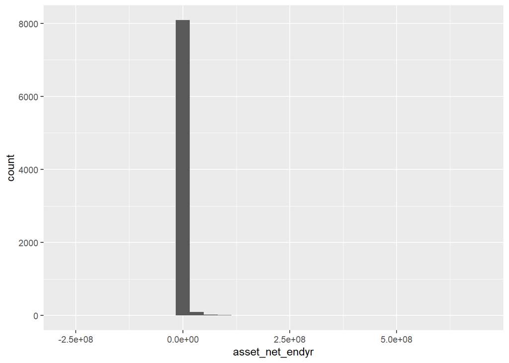

Q: How can we tell if we have outliers in this variable?  
A:

Let’s try the same data in a boxplot.

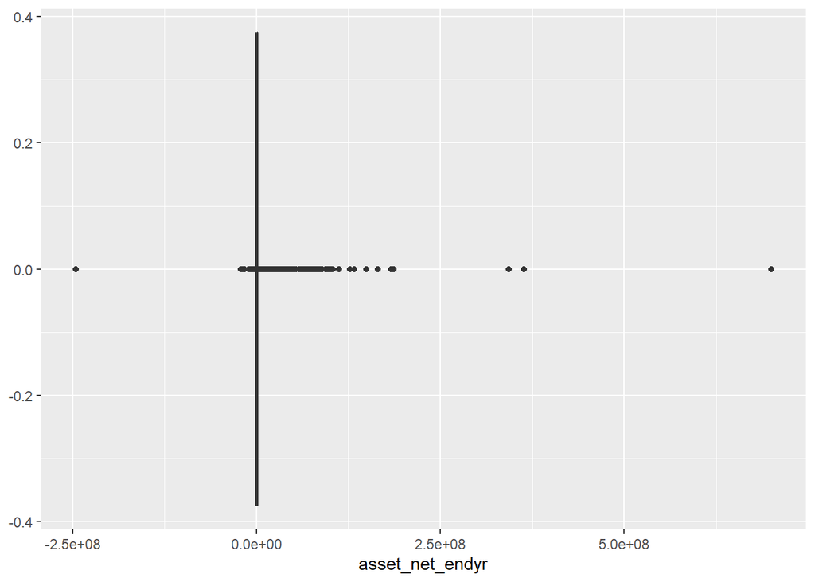

Q: What does a boxplot mark as a point (outlier)?  
A:

## Pulling locations from a boxplot

Well we can definitely see outliers here, but we have no way to know exactly what they are or where they are in our dataset. That’s where the following code comes in handy.

```
## # A tibble: 1,057 x 27
##    name_org             city  state formation_yr exempt_status.5~ gross_receipts
##    <fct>                <fct> <fct>        <dbl> <lgl>                     <dbl>
##  1 UNITY CHRISTIAN HIG~ HUDS~ MI            1972 TRUE                     819050
##  2 PLANO DEVELOPMENT C~ VISA~ CA            1979 TRUE                    1068037
##  3 WILLOW BROOK COUNTR~ TYLER TX            1922 NA                      6576048
##  4 UPSALA ELDER HOUSIN~ WORC~ MA            1993 TRUE                     585100
##  5 CONGREGATIONAL INVE~ OLEAN NY            1994 TRUE                    1388577
##  6 UNITED WAY OF OLMST~ ROCH~ MN            1925 TRUE                    4018725
##  7 COMMUNITY HEALTH CL~ NAMPA ID            1972 TRUE                   34089300
##  8 HOUSTON RHF HOUSING~ LONG~ CA            1997 TRUE                     585355
##  9 NATHAN HALE HOUSING~ LYNB~ NY              NA TRUE                    1481184
## 10 LENOIR COUNTY SPCA ~ KINS~ NC              NA TRUE                    1239557
## # ... with 1,047 more rows, and 21 more variables: voting_memb_ct <dbl>,
## #   income_tot_unrelated <dbl>, fundraise_expense_tot_curyr <dbl>,
## #   asset_tot_beginyr <dbl>, rev_giftsgrants_tot_curyr <dbl>,
## #   rev_investmt_curyr <dbl>, rev_prgmservice_curyr <dbl>, rev_tot_curyr <dbl>,
## #   grants_expense_tot_curyr <dbl>, benefits_expense_tot_curyr <dbl>,
## #   salaries_expense_tot_curyr <dbl>, expense_tot_curyr <dbl>,
## #   rev_less_expense_curyr <dbl>, asset_tot_endyr <dbl>, ...
```

```
## # A tibble: 8,239 x 28
##    name_org             city  state formation_yr exempt_status.5~ gross_receipts
##    <fct>                <fct> <fct>        <dbl> <lgl>                     <dbl>
##  1 The Grandville Educ~ Gran~ MI            1991 TRUE                      76705
##  2 COMMUNITY CENTER OF~ LA C~ CA            1948 TRUE                    1295372
##  3 ASSOCIATION OF SUBC~ DES ~ IL            1967 NA                      1021193
##  4 Mountain State Cong~ Park~ CO            1974 TRUE                     162867
##  5 FOREST CITY EDUCATI~ FORE~ IA            2008 TRUE                     459022
##  6 County Players Inc   Wapp~ NY            1979 TRUE                     278122
##  7 TOWER EDUCATION ASS~ ANN ~ MI            1995 TRUE                    2254794
##  8 UNITY CHRISTIAN HIG~ HUDS~ MI            1972 TRUE                     819050
##  9 Health for Humanity  Wads~ IL            1992 TRUE                     237692
## 10 BROWNSFERRY SPIRIT ~ Deca~ AL            2003 TRUE                     103112
## # ... with 8,229 more rows, and 22 more variables: voting_memb_ct <dbl>,
## #   income_tot_unrelated <dbl>, fundraise_expense_tot_curyr <dbl>,
## #   asset_tot_beginyr <dbl>, rev_giftsgrants_tot_curyr <dbl>,
## #   rev_investmt_curyr <dbl>, rev_prgmservice_curyr <dbl>, rev_tot_curyr <dbl>,
## #   grants_expense_tot_curyr <dbl>, benefits_expense_tot_curyr <dbl>,
## #   salaries_expense_tot_curyr <dbl>, expense_tot_curyr <dbl>,
## #   rev_less_expense_curyr <dbl>, asset_tot_endyr <dbl>, ...
```

Q: Why would this mutated column be helpful?  
A:

## Setting a percentile

```
## # A tibble: 166 x 27
##    name_org             city  state formation_yr exempt_status.5~ gross_receipts
##    <fct>                <fct> <fct>        <dbl> <lgl>                     <dbl>
##  1 PLANO DEVELOPMENT C~ VISA~ CA            1979 TRUE                    1068037
##  2 HOUSTON RHF HOUSING~ LONG~ CA            1997 TRUE                     585355
##  3 Family Apartments    Napa  CA            1990 TRUE                     353967
##  4 FRANCES HOUSE INC    GALE~ IL            1979 TRUE                   23936681
##  5 NEW BERN VOA ELDERL~ ALEX~ VA            1996 TRUE                     310527
##  6 LANCASTER RHF HOUSI~ LONG~ CA            2006 TRUE                     478910
##  7 CATHOLIC HOUSING OF~ MOBI~ AL            1975 TRUE                    1852129
##  8 FACULTY STUDENT ASS~ BUFF~ NY            1962 TRUE                   49349943
##  9 RAINTREE TOWER APAR~ BEAU~ TX            1977 NA                      1401729
## 10 ESSEX COUNTY COMMUN~ DANV~ MA            1998 TRUE                   27969872
## # ... with 156 more rows, and 21 more variables: voting_memb_ct <dbl>,
## #   income_tot_unrelated <dbl>, fundraise_expense_tot_curyr <dbl>,
## #   asset_tot_beginyr <dbl>, rev_giftsgrants_tot_curyr <dbl>,
## #   rev_investmt_curyr <dbl>, rev_prgmservice_curyr <dbl>, rev_tot_curyr <dbl>,
## #   grants_expense_tot_curyr <dbl>, benefits_expense_tot_curyr <dbl>,
## #   salaries_expense_tot_curyr <dbl>, expense_tot_curyr <dbl>,
## #   rev_less_expense_curyr <dbl>, asset_tot_endyr <dbl>, ...
```

```
## # A tibble: 8,239 x 28
##    name_org             city  state formation_yr exempt_status.5~ gross_receipts
##    <fct>                <fct> <fct>        <dbl> <lgl>                     <dbl>
##  1 The Grandville Educ~ Gran~ MI            1991 TRUE                      76705
##  2 COMMUNITY CENTER OF~ LA C~ CA            1948 TRUE                    1295372
##  3 ASSOCIATION OF SUBC~ DES ~ IL            1967 NA                      1021193
##  4 Mountain State Cong~ Park~ CO            1974 TRUE                     162867
##  5 FOREST CITY EDUCATI~ FORE~ IA            2008 TRUE                     459022
##  6 County Players Inc   Wapp~ NY            1979 TRUE                     278122
##  7 TOWER EDUCATION ASS~ ANN ~ MI            1995 TRUE                    2254794
##  8 UNITY CHRISTIAN HIG~ HUDS~ MI            1972 TRUE                     819050
##  9 Health for Humanity  Wads~ IL            1992 TRUE                     237692
## 10 BROWNSFERRY SPIRIT ~ Deca~ AL            2003 TRUE                     103112
## # ... with 8,229 more rows, and 22 more variables: voting_memb_ct <dbl>,
## #   income_tot_unrelated <dbl>, fundraise_expense_tot_curyr <dbl>,
## #   asset_tot_beginyr <dbl>, rev_giftsgrants_tot_curyr <dbl>,
## #   rev_investmt_curyr <dbl>, rev_prgmservice_curyr <dbl>, rev_tot_curyr <dbl>,
## #   grants_expense_tot_curyr <dbl>, benefits_expense_tot_curyr <dbl>,
## #   salaries_expense_tot_curyr <dbl>, expense_tot_curyr <dbl>,
## #   rev_less_expense_curyr <dbl>, asset_tot_endyr <dbl>, ...
```

## What do we do with outliers?

When we encounter NAs we have a couple options. We may want to use one or the other depending on if the outliers are mistakes, and what kind of analysis we want to do. We have four main options:

1. We can try to figure out what kind of value was supposed to be in that place and replace it with that value.
2. We can consider them missing data and replace them with NAs.
3. We can try our analysis twice, once with outliers and once without to see if it makes a difference.
4. We can allow for extreme values in our dataset and continue on with our analysis.

Let’s look at some of these options.

```
##                                              name_org             city
##  BENEVOLENT & PROTECTIVE ORDER OF ELKS           :  15   NEW YORK   :  60
##  BENEVOLENT & PROTECTIVE ORDER OF ELKS OF THE USA:  13   WASHINGTON :  53
##  FRATERNAL ORDER OF EAGLES                       :  11   LOS ANGELES:  38
##  Benevolent & Protective Order of Elks of the USA:   9   ALEXANDRIA :  37
##  BENEVOLENT & PROTECTIVE ORDER OF                :   7   COLUMBIA   :  37
##  BENEVOLENT AND PROTECTIVE ORDER OF              :   7   LONG BEACH :  35
##  (Other)                                         :8177   (Other)    :7979
##      state       formation_yr  exempt_status.501c3 gross_receipts
##  CA     : 844   Min.   :1681   Mode:logical        Min.   :0.000e+00
##  NY     : 609   1st Qu.:1959   TRUE:4922           1st Qu.:1.639e+05
##  FL     : 418   Median :1982   NA's:3317           Median :3.232e+05
##  PA     : 368   Mean   :1974                       Mean   :1.735e+06
##  IL     : 330   3rd Qu.:1998                       3rd Qu.:7.838e+05
##  (Other):5668   Max.   :2017                       Max.   :1.056e+09
##  NA's   :   2   NA's   :931
##  voting_memb_ct     income_tot_unrelated fundraise_expense_tot_curyr
##  Min.   :    0.00   Min.   :-311919      Min.   :       0
##  1st Qu.:    6.00   1st Qu.:      0      1st Qu.:       0
##  Median :    9.00   Median :      0      Median :       0
##  Mean   :   36.34   Mean   :   8154      Mean   :   26843
##  3rd Qu.:   13.00   3rd Qu.:      0      3rd Qu.:       0
##  Max.   :35146.00   Max.   :3234375      Max.   :15330209
##
##  asset_tot_beginyr   rev_giftsgrants_tot_curyr rev_investmt_curyr
##  Min.   : -5431065   Min.   :        0         Min.   :-6977416
##  1st Qu.:   169056   1st Qu.:      367         1st Qu.:       3
##  Median :   519134   Median :    33567         Median :     245
##  Mean   :  2672009   Mean   :   609591         Mean   :   61578
##  3rd Qu.:  1374574   3rd Qu.:   181648         3rd Qu.:    6438
##  Max.   :778124909   Max.   :704248801         Max.   :44681898
##  NA's   :63
##  rev_prgmservice_curyr rev_tot_curyr       grants_expense_tot_curyr
##  Min.   :      -52     Min.   : -4781906   Min.   :    -2544
##  1st Qu.:        0     1st Qu.:   117856   1st Qu.:        0
##  Median :    39034     Median :   252630   Median :        0
##  Mean   :   635761     Mean   :  1380039   Mean   :   161373
##  3rd Qu.:   261417     3rd Qu.:   604287   3rd Qu.:     2000
##  Max.   :290939912     Max.   :712607258   Max.   :253101533
##
```

[output cut: 17 more lines]

```
##  Min.   :-245794076   no :7766            no :5774
##  1st Qu.:    114355   yes: 473            yes:2465
##  Median :    398765
##  Mean   :   1963598
##  3rd Qu.:   1070896
##  Max.   : 699546633
##
##  conflict_interest_policy enforce_conflict_policy whistleblower_policy
##  no :4545                 no  :1665               no :5935
##  yes:3694                 yes :2990               yes:2304
##                           NA's:3584
##
##
##
##
```

*Replace them with NAs.* Create a new copy of the dataset. Use either method (boxplot or percentiles) to find the outliers in the rev_prgmservice_curyr variable. Then replace those values with NAs. How will you know if it worked?

*Try the analysis twice* This means we have to make an entirely new subset with no outliers. Make another new copy of the irs dataset. This time create a function (or more than one funtion) to go through and remove all rows with outliers within the percentiles of .001 and .999 from the whole dataset.

# Date Times

## How is a date stored?

We will mostly deal with three different date-time formats in R: Date, POSIXct and POSIXlt.

*Date* columns are in this format: 2022-03-06 (YYYY-MM-DD). In the background they store as the number of days since Jan 1, 1970. Look at the two dates below.

```
## [1] 19057
```

```
## [1] 0
```

*POSIXct* is in this format: 2022-03-06 00:00:00. This class stores date/time values as the number of seconds since January 1, 1970 UTC. (UTC is the universal time zone which goes through Greenwich, England and the prime meridian). Note the hour is in 24 hour format not am/pm.

```
## [1] "2020-03-06 13:04:45 MST"
```

```
## [1] 1583525040
```

*POSIXlt* on the surface looks and works like POSIXct but it instead stores as a list with elements for second, minute, hour, day, month, and year. We will use POSIXct more often.

## Getting datetimes into the right format

It would be great if everyone put date-times in the YYYY-MM-DD HH:MM:SS format. Unfortunately they don’t, and when that is the case we need to tell R what format the date time is *currently* in. That’s where the table in on the canvas page comes into play. Use that table for the following challenges.

```
## [1] "2022-03-06 13:35:00 MST"
```

```
## [1] "1994-02-21"
```

```
## [1] "June 18, 2009- 14:56"
```

```
## [1] "Wednesday 8:36 pm on Jan. 3, 1945"
```

## Pulling other information out of date times.

Once you have your date or time in a format that R can understand, you can extract all sorts of information from it using the format() function. To do this you will also use the table on canvas.

```
## [1] "09"
```

```
## [1] "Friday"
```

```
## [1] "2021-12-25"
```

```
## [1] "12/25/2021"
```

## Importing date times with readr

One of the reasons we usually import with read_csv is that it is typically better at seeing date times than read.csv. But sometimes it still needs help. Let’s look at how we do that.

Import the indianapolis_use_of_force dataset. Make the date column date format.

## Date times in other packages

There are also other date time functions in other packages. The lubridate package for example has other functions that can help you extract information. Look at the following code and see if you can understand what is happening.

```
## [1] 2020.1
```

```
## [1] FALSE
```

```
## [1] FALSE
```

```
## [1] TRUE
```

```
## [1] "2020-03-06 MST"
```

```
## [1] "2020-03-01 MST"
```

```
## [1] "2021-01-01 MST"
```

## Time zones

As you may have noticed, R assumes the time zone is the current time zone of your computer. That may be fine, but if you are looking at the absolute time of some event it may be helpful to move a date time between time zones. Take a look at these three functions.

[output not shown]

[output cut: 284 more lines]

```
## [1] "2020-03-06 15:04:45 EST"
```

```
## [1] "2020-03-06 13:04:45 MST"
```